# Project Background

Markus Min

2025-05-20

## Background

The factors that determine the marine survival and therefore recruitment of salmonid populations have long been of interest to ecologists and fisheries managers, and are a key determinant of the recovery of ESA-listed populations. Marine survival varies considerably both between salmon stocks and between years, as evinced by large variations in Smolt-to-Adult return (SAR) estimates (Sharma and Liermann 2010). This is evident in the Columbia River Basin, as seen in the following plots of SAR for three different populations:

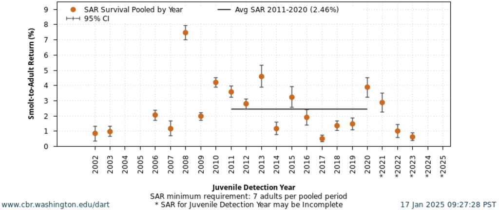

Smolt-to-Adult Return (SAR) Survival, Bonneville (Juvenile) to Bonneville (Adult). PIT-Tagged Snake River Fall Chinook ESU.

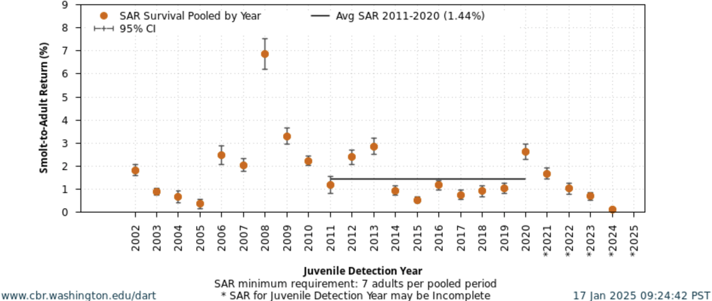

Smolt-to-Adult Return (SAR) Survival, Bonneville (Juvenile) to Bonneville (Adult). PIT-Tagged Snake River Spring/Summer Chinook ESU.

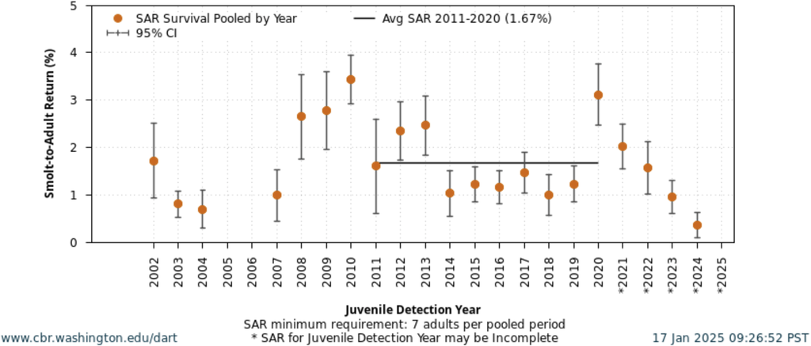

Smolt-to-Adult Return (SAR) Survival, Bonneville (Juvenile) to Bonneville (Adult). PIT-Tagged Upper Columbia Spring Chinook ESU.

Unraveling the factors that underlie variation in smolt-to-adult returns begins before salmonids even enter the marine environment. The freshwater experiences of juvenile salmon affect their survival in the ocean environment, in what are known as carryover effects (Gosselin et al. 2018). Influential carryover effects include rearing type, in-river transportation (i.e., barged vs. not barged), snow-water equivalent, river temperature, and oumtmigration timing (Scheuerell et al. 2009, Gosselin et al. 2018, 2021). Then, upon entering the Columbia River Estuary, outmigrating smolts encounter numerous predators, conspicuous among them nesting seabirds such as Caspian Terns, whose predation rates exceeded 20% of outmigrating smolts of some ESA-listed populations prior to management interventions that brought these predation rates down considerably (Collis et al. 2024).

Once juveniles reach the oceanic environment, our conceptual understanding of marine survival is based primarily on the foundational work of Pearcy (1992) and Beamish and Mahnken (2001), who argued that marine survival is determined early in the oceanic phase, with survival being dependent on the ability to avoid predation and feed to satisfy metabolic requirements. An underlying and possibly unifying process that underlies marine survival is the “growth-mortality hypothesis” (Anderson 1988, Miller et al. 1988), which states that growth of juvenile fish is a primary determinant of mortality, given that predation is often size-dependent. Multiple studies have found evidence to support this hypothesis for Columbia River salmon. Studies of marine survival in Snake River spring/summer (Miller et al. 2014) and Columbia River spring Chinook salmon (Tomaro et al. 2012) found that marine growth and size at capture were strongly positively related to survival. Furthermore, direct evidence of predation on juvenile Chinook salmon by Pacific Hake and Jack Mackerel appears to support this hypothesis, as only small juvenile salmonids were found in predator stomachs (Emmett and Krutzikowsky 2008).

Outgrowing size-dependent mortality and meeting metabolic needs are each ultimately related to food availability. In the classical recruitment literature, many hypotheses are put forward that describe the conditions necessary for fish to feed and grow. The first of these is known as the “match-mismatch hypothesis,” which states that the degree of spatiotemporal match or mismatch between fish and their prey leads to variable year class strength (Cushing 1975, Cushing 1990). A second is the “Stable Ocean Hypothesis” as put forward by Reuben Lasker, which stated that it was not only the abundance of food, but also the degree of aggregation of food (which a stable, i.e., not turbulent, ocean was necessary for) that provided for good feeding conditions (Lasker 1981). A third hypothesis, which is related to Lasker’s Stable Ocean Hypothesis, is the Optimal Environmental Window hypothesis (Cury and Roy 1989). This states that in Ekman-type (wind-driven) upwelling systems, there exists an optimal window for larval and juvenile fish survival (and therefore recruitment). This optimal window is the result of the dome-shaped relationship between upwelling (which is related to turbulence) and recruitment. This is because at higher wind speeds, despite higher primary productivity, mixing begins to occur and disrupts the food aggregations necessary for larval fish to feed on, leading to a tradeoff between food availability and turbulence.

There have been multiple studies that have attempted to examine these hypotheses as they pertain to Columbia River salmonids, with mixed results. To test the match-mismatch hypothesis, Tomaro et al. (2012) used four indicators: two indices of the copepod community based on sampling from the Newport Hydrographic Line (NHL), the lag between the physical spring transition date and juvenile emigration, and the lag between the biological spring transition date and juvenile emigration. They found no relationship between these four indicators and growth, did find a relationship between size at capture of juvenile salmonids and both the abundance of lipid-rich copepods and the timing of biological spring transition (Tomaro et al. 2012). In a similar study, Miller et al. (2014) investigated the relationship between SAR and PDO, NPGO, an index of the copepod community from the NHL, the Columbia River Plume area, and the same lags between physical and biological transition dates and juvenile emigration. They found that some of these indicators performed well for hindcasting, but very poorly for forecasting (Miller et al. 2014). In a multivariate analysis of Columbia River Basin returns, Burke et al. (2013) found that almost every indicator related to growth and feeding was informative, as were the PDO and ONI indices.

Across these studies, a major limitation is a lack of spatial information, as evinced by the coarse indicators used. While basin-scale indicators like PDO and NPGO have historically been useful for predicting salmon returns, these correlations appear to be breaking down (Litzow et al. 2020), as correlations between these basin-scale indicators and local environmental indices continually change (Gosselin et al. 2021). As a result, spatially resolved data that better reflects the restricted and stock-specific areas used by juvenile salmon in their early marine residence (Teel et al. 2015) may improve our mechanistic understanding of drivers of marine survival.

Multiple fisheries-independent surveys are operated in the Northern California Current that may provide an opportunity to uncover these mechanistic relationships. The first of these is the Juvenile Salmon and Ocean Ecosystem Survey (JSOES), which targets juvenile salmonids during the early part of their oceanic phase. The JSOES survey, which occurs in the summer, provides a snapshot of the distribution and abundance of juvenile salmonids, which migrate through the survey area at different rates, depending on their natal origin (Fisher et al. 2014). While the JSOES collects monitors some other aspects of the ecosystem, other datasets are required that better sample other members of the marine food web; these surveys include the Pre-Recruit Survey, the Hake Survey, and California Current Ecosystem Survey, each of which are described under the “Survey Descriptions” tab. By integrating these datasets and using species distribution models, spatiotemporal overlap between juvenile salmonids, their predators, competitors, and prey can be estimated, and the degree of overlap used to test how food web interactions affect marine survival.

## References

Anderson, J. T. 1988. A review of size dependent survival during pre-recruit stages of fishes in relation to recruitment. Journal of Northwest Atlantic Fishery Science 8:55–66.

Beamish, R. J., and C. Mahnken. 2001. A critical size and period hypothesis to explain natural regulation of salmon abundance and the linkage to climate and climate change. Progress in Oceanography 49:423–437.

Burke, B. J., W. T. Peterson, B. R. Beckman, C. Morgan, E. A. Daly, and M. Litz. 2013. [Multivariate Models of Adult Pacific Salmon Returns](https://doi.org/10.1371/journal.pone.0054134). PLoS ONE 8.

Collis, K., D. D. Roby, A. F. Evans, T. J. Lawes, and D. E. Lyons. 2024. [Caspian Tern Management to Increase Survival of Juvenile Salmonids in the Columbia River Basin: Progress and Adaptive Management Considerations](https://doi.org/10.1002/fsh.11012). Fisheries 49:71–84.

Cury, P., and C. Roy. 1989. Optimal environmental window and pelagic fish recruitment success in upwelling areas. Canadian Journal of Fisheries and Aquatic Sciences 46:670–680.

Cushing, D. H. 1975. Marine ecology and fisheries. CUP archive.

Cushing, D. H. 1990. Plankton production and year-class strength in fish populations: an update of the match/mismatch hypothesis. Pages 249–293 Advances in marine biology. Elsevier.

Emmett, R. L., and G. K. Krutzikowsky. 2008. [Nocturnal Feeding of Pacific Hake and Jack Mackerel off the Mouth of the Columbia River, 1998‐2004: Implications for Juvenile Salmon Predation](https://doi.org/10.1577/t06-058.1). Transactions of the American Fisheries Society 137:657–676.

Fisher, J. P., L. A. Weitkamp, D. J. Teel, S. A. Hinton, J. A. Orsi, E. V. Farley, J. F. T. Morris, M. E. Thiess, R. M. Sweeting, and M. Trudel. 2014. [Early Ocean Dispersal Patterns of Columbia River Chinook and Coho Salmon](https://doi.org/10.1080/00028487.2013.847862). Transactions of the American Fisheries Society 143:252–272.

Gosselin, J. L., E. R. Buhle, C. Van Holmes, W. N. Beer, S. Iltis, and J. J. Anderson. 2021. [Role of carryover effects in conservation of wild Pacific salmon migrating regulated rivers](https://doi.org/10.1002/ecs2.3618). Ecosphere 12.

Gosselin, J. L., R. W. Zabel, J. J. Anderson, J. R. Faulkner, A. M. Baptista, and B. P. Sandford. 2018. [Conservation planning for freshwater–marine carryover effects on Chinook salmon survival](https://doi.org/10.1002/ece3.3663). Ecology and Evolution 8:319–332.

Lasker, R. 1981. The role of a stable ocean in larval fish survival and subsequent recruitment. Marine fish larvae: morphology, ecology and relation to fisheries 1:80–89.

Litzow, M. A., M. E. Hunsicker, N. A. Bond, B. J. Burke, C. J. Cunningham, J. L. Gosselin, E. L. Norton, E. J. Ward, and S. G. Zador. 2020. [The changing physical and ecological meanings of North Pacific Ocean climate indices](https://doi.org/10.1073/pnas.1921266117). Proceedings of the National Academy of Sciences of the United States of America 117:7665–7671.

Miller, J. A., D. J. Teel, W. T. Peterson, and A. M. Baptista. 2014. [Assessing the relative importance of local and regional processes on the survival of a threatened salmon population](https://doi.org/10.1371/journal.pone.0099814). PLoS ONE 9.

Miller, T. J., L. B. Crowder, J. A. Rice, and E. A. Marschall. 1988. Larval size and recruitment mechanisms in fishes: toward a conceptual framework. Canadian Journal of Fisheries and Aquatic Sciences 45:1657–1670.

Pearcy, W. G. 1992. Ocean ecology of North Pacific salmonids. (No Title).

Scheuerell, M. D., R. W. Zabel, and B. P. Sandford. 2009. [Relating juvenile migration timing and survival to adulthood in two species of threatened Pacific salmon (Oncorhynchus spp.)](https://doi.org/10.1111/j.1365-2664.2009.01693.x). Journal of Applied Ecology 46:983–990.

Sharma, R., and M. Liermann. 2010. [Using hierarchical models to estimate effects of ocean anomalies on north-west Pacific Chinook salmon Oncorhynchus tshawytscha recruitment](https://doi.org/10.1111/j.1095-8649.2010.02779.x). Journal of Fish Biology 77:1948–1963.

Teel, D. J., B. J. Burke, D. R. Kuligowski, C. A. Morgan, and D. M. Van Doornik. 2015. [Genetic identification of chinook salmon: Stock-specific distributions of juveniles along the Washington and oregon coasts](https://doi.org/10.1080/19425120.2015.1045961). Marine and Coastal Fisheries 7:274–300.

Tomaro, L. M., D. J. Teel, W. T. Peterson, and J. A. Miller. 2012. [When is bigger better? Early marine residence of middle and upper Columbia River spring Chinook salmon](https://doi.org/10.3354/meps09620). Marine Ecology Progress Series 452:237–252.